# SR_01_DISREG_ENTITY_ADDR_CITY

Disregarded entity city · Text report

## Overview

**Description**

Address Foreign - City

**Table**

`SR-P01-T01-ID-DISREGARDED-ENTITIES` (many)

**Location code**

`SCHED-R-PART-01-COL-A`

**Family**

`SCHED-R-PART-01-COL-A` · siblings: SR_01_DISREG_ENTITY_ADDR_CNTR, SR_01_DISREG_ENTITY_ADDR_L1, SR_01_DISREG_ENTITY_ADDR_L2, SR_01_DISREG_ENTITY_ADDR_STATE, SR_01_DISREG_ENTITY_ADDR_ZIP, SR_01_DISREG_ENTITY_EIN

**Data type**

text (xsd: TextType, CityType)

**Scope**

PC

**Status**

unreviewed

6

xpaths mapped (6 observed)

117,351

filings with a value

2009–2024

tax years observed

4

open flags (1 errors)

## Flags

| Severity | Flag | Xpath | Detail |
| --- | --- | --- | --- |
| ⚠ error | `COLLISION` | IRS990ScheduleR/IdDisregardedEntitiesGrp/ForeignAddress/CityNm | 750 filings contain 2+ of its xpaths; most common set: /Return/ReturnData/IRS990ScheduleR/IdDisregardedEntitiesGrp/ForeignAddress/CityNm ; /Return/ReturnData/IRS990ScheduleR/IdDisregardedEntitiesGrp/U… |
| ⓘ info | `MANY_NOT_REPEATING` | IRS990ScheduleR/IdDisregardedEntitiesGrp/USAddress/CityNm | many-to-one table, but 58% of values sit in no repeating element |
| ⓘ info | `MANY_NOT_REPEATING` | IRS990ScheduleR/Form990ScheduleRPartI/AddressUS/City | many-to-one table, but 58% of values sit in no repeating element |
| ⓘ info | `MANY_NOT_REPEATING` | IRS990ScheduleR/IdDisregardedEntitiesGrp/USAddress/City | many-to-one table, but 58% of values sit in no repeating element |

## Xpaths

All mapped xpaths (under /Return/ReturnData or /Return/ReturnHeader), oldest first. Charts label each series by its xpath.

| Xpath | Form | Chart label | First year | Last year | Versions | Filings | Repeats in |
| --- | --- | --- | --- | --- | --- | --- | --- |
| IRS990ScheduleR/Form990ScheduleRPartI/AddressUS/City | Sched R | same | 2009 | 2012 | 17 | 15,198 | 41.7% |
| IRS990ScheduleR/Form990ScheduleRPartI/AddressForeign/City | Sched R | same | 2009 | 2012 | 15 | 268 | 22.0% |
| IRS990ScheduleR/IdDisregardedEntitiesGrp/USAddress/City | Sched R | same | 2013 | 2013 | 3 | 5,674 | 41.6% |
| IRS990ScheduleR/IdDisregardedEntitiesGrp/ForeignAddress/City | Sched R | same | 2013 | 2013 | 3 | 106 | 23.6% |
| IRS990ScheduleR/IdDisregardedEntitiesGrp/USAddress/CityNm | Sched R | same | 2014 | 2024 | 34 | 94,365 | 41.7% |
| IRS990ScheduleR/IdDisregardedEntitiesGrp/ForeignAddress/CityNm | Sched R | …0ScheduleR/IdDisregardedEntitiesGrp/ForeignAddress/CityNm | 2014 | 2024 | 33 | 1,740 | 38.0% |

## Coverage

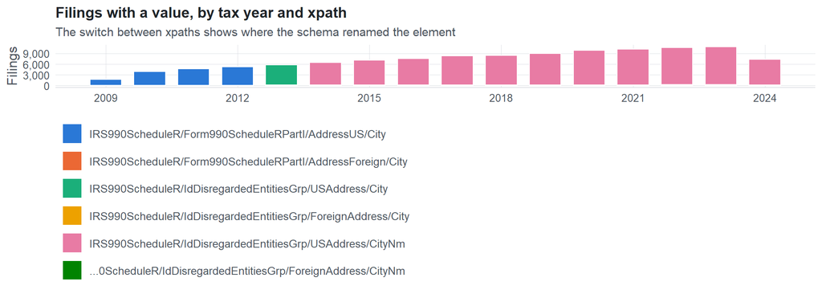

**Table view**

Table view: filings by tax year and series

| Tax year | IRS990ScheduleR/Form990ScheduleRPartI/AddressUS/City | IRS990ScheduleR/Form990ScheduleRPartI/AddressForeign/City | IRS990ScheduleR/IdDisregardedEntitiesGrp/USAddress/City | IRS990ScheduleR/IdDisregardedEntitiesGrp/ForeignAddress/City | IRS990ScheduleR/IdDisregardedEntitiesGrp/USAddress/CityNm | …0ScheduleR/IdDisregardedEntitiesGrp/ForeignAddress/CityNm |
| --- | --- | --- | --- | --- | --- | --- |
| 2009 | 1,642 | 39 | 0 | 0 | 0 | 0 |
| 2010 | 3,830 | 71 | 0 | 0 | 0 | 0 |
| 2011 | 4,569 | 76 | 0 | 0 | 0 | 0 |
| 2012 | 5,157 | 82 | 0 | 0 | 0 | 0 |
| 2013 | 0 | 0 | 5,674 | 106 | 0 | 0 |
| 2014 | 0 | 0 | 0 | 0 | 6,371 | 111 |
| 2015 | 0 | 0 | 0 | 0 | 6,972 | 121 |
| 2016 | 0 | 0 | 0 | 0 | 7,455 | 127 |
| 2017 | 0 | 0 | 0 | 0 | 8,214 | 132 |
| 2018 | 0 | 0 | 0 | 0 | 8,351 | 140 |
| 2019 | 0 | 0 | 0 | 0 | 8,893 | 158 |
| 2020 | 0 | 0 | 0 | 0 | 9,670 | 182 |
| 2021 | 0 | 0 | 0 | 0 | 10,045 | 192 |
| 2022 | 0 | 0 | 0 | 0 | 10,486 | 203 |
| 2023 | 0 | 0 | 0 | 0 | 10,704 | 214 |
| 2024 | 0 | 0 | 0 | 0 | 7,204 | 160 |

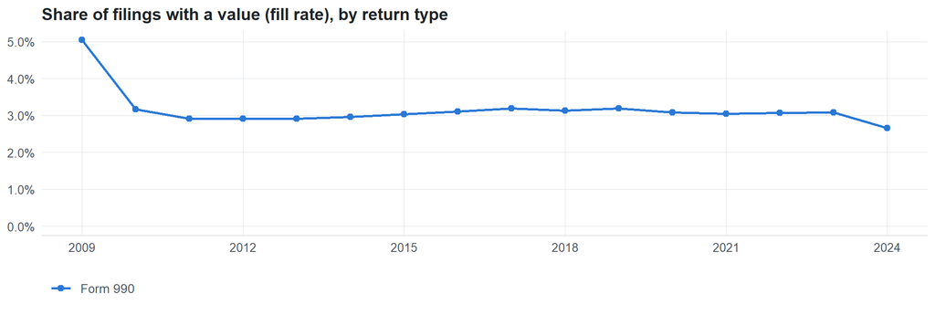

**Table view**

Table view: fill rate

| Tax year | Return type | Filings | All filings | Fill rate |
| --- | --- | --- | --- | --- |
| 2009 | Form 990 | 1,681 | 33,311 | 5.05% |
| 2010 | Form 990 | 3,901 | 123,025 | 3.17% |
| 2011 | Form 990 | 4,645 | 159,504 | 2.91% |
| 2012 | Form 990 | 5,239 | 179,688 | 2.92% |
| 2013 | Form 990 | 5,780 | 198,855 | 2.91% |
| 2014 | Form 990 | 6,482 | 218,619 | 2.96% |
| 2015 | Form 990 | 7,093 | 233,519 | 3.04% |
| 2016 | Form 990 | 7,582 | 243,903 | 3.11% |
| 2017 | Form 990 | 8,346 | 261,612 | 3.19% |
| 2018 | Form 990 | 8,491 | 271,442 | 3.13% |
| 2019 | Form 990 | 9,051 | 283,694 | 3.19% |
| 2020 | Form 990 | 9,852 | 320,342 | 3.08% |
| 2021 | Form 990 | 10,237 | 336,480 | 3.04% |
| 2022 | Form 990 | 10,689 | 349,055 | 3.06% |
| 2023 | Form 990 | 10,918 | 354,768 | 3.08% |
| 2024 | Form 990 | 7,364 | 277,298 | 2.66% |

## Repeating groups

Table cardinality in the concordance: **many**. 6 of 6 observed xpaths repeat within a filing.

Repeating element each xpath was observed in (from the raw indexed xpath)

| Xpath | Repeating element | Filings (summed over years) |
| --- | --- | --- |
| IRS990ScheduleR/Form990ScheduleRPartI/AddressForeign/City | (none) | 113 |
| IRS990ScheduleR/Form990ScheduleRPartI/AddressForeign/City | IRS990ScheduleR/Form990ScheduleRPartI | 155 |
| IRS990ScheduleR/Form990ScheduleRPartI/AddressUS/City | (none) | 8811 |
| IRS990ScheduleR/Form990ScheduleRPartI/AddressUS/City | IRS990ScheduleR/Form990ScheduleRPartI | 6387 |
| IRS990ScheduleR/IdDisregardedEntitiesGrp/ForeignAddress/City | (none) | 39 |
| IRS990ScheduleR/IdDisregardedEntitiesGrp/ForeignAddress/City | IRS990ScheduleR/IdDisregardedEntitiesGrp | 67 |
| IRS990ScheduleR/IdDisregardedEntitiesGrp/USAddress/City | (none) | 3283 |
| IRS990ScheduleR/IdDisregardedEntitiesGrp/USAddress/City | IRS990ScheduleR/IdDisregardedEntitiesGrp | 2391 |
| IRS990ScheduleR/IdDisregardedEntitiesGrp/ForeignAddress/CityNm | (none) | 751 |
| IRS990ScheduleR/IdDisregardedEntitiesGrp/ForeignAddress/CityNm | IRS990ScheduleR/IdDisregardedEntitiesGrp | 989 |
| IRS990ScheduleR/IdDisregardedEntitiesGrp/USAddress/CityNm | (none) | 54639 |
| IRS990ScheduleR/IdDisregardedEntitiesGrp/USAddress/CityNm | IRS990ScheduleR/IdDisregardedEntitiesGrp | 39726 |

## Values

| Result | Check | Detail |
| --- | --- | --- |
| ✓ pass | Values are text, not numbers | 0% of values are numeric |
| ⓘ info | No sign of truncation | IRS990ScheduleR/Form990ScheduleRPartI/AddressForeign/City: longest value is exactly 35 characters; IRS990ScheduleR/IdDisregardedEntitiesGrp/ForeignAddress/City: longest value is exactly 35 characters;… |
| ✓ pass | No dominant boilerplate value | most common value covers 14% of filings: “LONDON” |

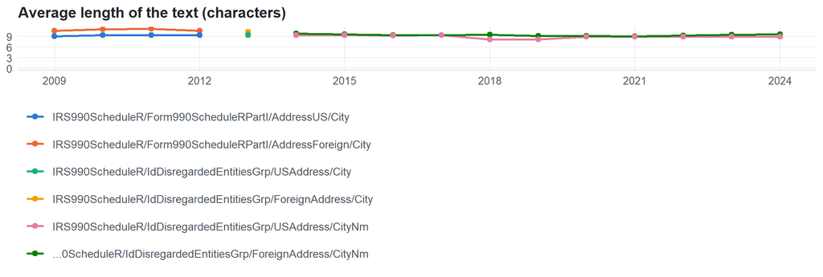

**Table view**

Table view: length and variety by tax year

| Series | Tax year | Filings | Avg length | Max length | Distinct values (approx.) |
| --- | --- | --- | --- | --- | --- |
| IRS990ScheduleR/Form990ScheduleRPartI/AddressUS/City | 2009 | 1,642 | 9 | 22 | 1,054 |
| IRS990ScheduleR/Form990ScheduleRPartI/AddressUS/City | 2010 | 3,830 | 9 | 22 | 1,049 |
| IRS990ScheduleR/Form990ScheduleRPartI/AddressUS/City | 2011 | 4,569 | 9 | 22 | 1,015 |
| IRS990ScheduleR/Form990ScheduleRPartI/AddressUS/City | 2012 | 5,157 | 9 | 22 | 1,412 |
| IRS990ScheduleR/Form990ScheduleRPartI/AddressForeign/City | 2009 | 39 | 11 | 35 | 30 |
| IRS990ScheduleR/Form990ScheduleRPartI/AddressForeign/City | 2010 | 71 | 11 | 35 | 51 |
| IRS990ScheduleR/Form990ScheduleRPartI/AddressForeign/City | 2011 | 76 | 11 | 35 | 55 |
| IRS990ScheduleR/Form990ScheduleRPartI/AddressForeign/City | 2012 | 82 | 11 | 35 | 67 |
| IRS990ScheduleR/IdDisregardedEntitiesGrp/USAddress/City | 2013 | 5,674 | 9 | 22 | 990 |
| IRS990ScheduleR/IdDisregardedEntitiesGrp/ForeignAddress/City | 2013 | 106 | 10 | 35 | 59 |
| IRS990ScheduleR/IdDisregardedEntitiesGrp/USAddress/CityNm | 2014 | 6,371 | 9 | 22 | 1,386 |
| IRS990ScheduleR/IdDisregardedEntitiesGrp/USAddress/CityNm | 2015 | 6,972 | 9 | 22 | 1,468 |
| IRS990ScheduleR/IdDisregardedEntitiesGrp/USAddress/CityNm | 2016 | 7,455 | 9 | 22 | 2,286 |
| IRS990ScheduleR/IdDisregardedEntitiesGrp/USAddress/CityNm | 2017 | 8,214 | 9 | 22 | 1,860 |
| IRS990ScheduleR/IdDisregardedEntitiesGrp/USAddress/CityNm | 2018 | 8,351 | 8 | 22 | 2,086 |
| IRS990ScheduleR/IdDisregardedEntitiesGrp/USAddress/CityNm | 2019 | 8,893 | 8 | 22 | 1,475 |
| IRS990ScheduleR/IdDisregardedEntitiesGrp/USAddress/CityNm | 2020 | 9,670 | 9 | 22 | 1,529 |
| IRS990ScheduleR/IdDisregardedEntitiesGrp/USAddress/CityNm | 2021 | 10,045 | 9 | 22 | 2,020 |
| IRS990ScheduleR/IdDisregardedEntitiesGrp/USAddress/CityNm | 2022 | 10,486 | 9 | 22 | 2,417 |
| IRS990ScheduleR/IdDisregardedEntitiesGrp/USAddress/CityNm | 2023 | 10,704 | 9 | 22 | 1,523 |
| IRS990ScheduleR/IdDisregardedEntitiesGrp/USAddress/CityNm | 2024 | 7,204 | 9 | 21 | 1,393 |
| …0ScheduleR/IdDisregardedEntitiesGrp/ForeignAddress/CityNm | 2014 | 111 | 10 | 29 | 87 |
| …0ScheduleR/IdDisregardedEntitiesGrp/ForeignAddress/CityNm | 2015 | 121 | 10 | 35 | 103 |
| …0ScheduleR/IdDisregardedEntitiesGrp/ForeignAddress/CityNm | 2016 | 127 | 9 | 28 | 163 |
| …0ScheduleR/IdDisregardedEntitiesGrp/ForeignAddress/CityNm | 2017 | 132 | 9 | 28 | 141 |
| …0ScheduleR/IdDisregardedEntitiesGrp/ForeignAddress/CityNm | 2018 | 140 | 9 | 31 | 138 |
| …0ScheduleR/IdDisregardedEntitiesGrp/ForeignAddress/CityNm | 2019 | 158 | 9 | 31 | 141 |
| …0ScheduleR/IdDisregardedEntitiesGrp/ForeignAddress/CityNm | 2020 | 182 | 9 | 31 | 133 |
| …0ScheduleR/IdDisregardedEntitiesGrp/ForeignAddress/CityNm | 2021 | 192 | 9 | 28 | 228 |
| …0ScheduleR/IdDisregardedEntitiesGrp/ForeignAddress/CityNm | 2022 | 203 | 9 | 33 | 248 |
| …0ScheduleR/IdDisregardedEntitiesGrp/ForeignAddress/CityNm | 2023 | 214 | 9 | 33 | 140 |
| …0ScheduleR/IdDisregardedEntitiesGrp/ForeignAddress/CityNm | 2024 | 160 | 10 | 28 | 147 |

Most common values by xpath (all years; long values truncated)

| Series | Value | Filings | Share |
| --- | --- | --- | --- |
| IRS990ScheduleR/Form990ScheduleRPartI/AddressUS/City | ALEXANDRIA | 469 | 3.1% |
| IRS990ScheduleR/Form990ScheduleRPartI/AddressUS/City | NEW YORK | 282 | 1.9% |
| IRS990ScheduleR/Form990ScheduleRPartI/AddressUS/City | SAN FRANCISCO | 272 | 1.8% |
| IRS990ScheduleR/Form990ScheduleRPartI/AddressUS/City | LOS ANGELES | 200 | 1.3% |
| IRS990ScheduleR/Form990ScheduleRPartI/AddressUS/City | WASHINGTON | 200 | 1.3% |
| IRS990ScheduleR/Form990ScheduleRPartI/AddressUS/City | COLUMBUS | 150 | 1.0% |
| IRS990ScheduleR/Form990ScheduleRPartI/AddressUS/City | BOSTON | 140 | 0.9% |
| IRS990ScheduleR/Form990ScheduleRPartI/AddressUS/City | Alexandria | 128 | 0.8% |
| IRS990ScheduleR/Form990ScheduleRPartI/AddressUS/City | Troy | 115 | 0.8% |
| IRS990ScheduleR/Form990ScheduleRPartI/AddressUS/City | CHICAGO | 109 | 0.7% |
| IRS990ScheduleR/Form990ScheduleRPartI/AddressUS/City | FOSTER CITY | 91 | 0.6% |
| IRS990ScheduleR/Form990ScheduleRPartI/AddressUS/City | GRAND RAPIDS | 75 | 0.5% |
| IRS990ScheduleR/Form990ScheduleRPartI/AddressUS/City | FARMINGTON HILLS | 56 | 0.4% |
| IRS990ScheduleR/Form990ScheduleRPartI/AddressUS/City | CADILLAC | 55 | 0.4% |
| IRS990ScheduleR/Form990ScheduleRPartI/AddressUS/City | LIVONIA | 55 | 0.4% |
| IRS990ScheduleR/Form990ScheduleRPartI/AddressUS/City | ONTARIO | 55 | 0.4% |
| IRS990ScheduleR/Form990ScheduleRPartI/AddressUS/City | INDIANAPOLIS | 52 | 0.3% |
| IRS990ScheduleR/Form990ScheduleRPartI/AddressUS/City | WARREN | 46 | 0.3% |
| IRS990ScheduleR/Form990ScheduleRPartI/AddressUS/City | BALTIMORE | 45 | 0.3% |
| IRS990ScheduleR/Form990ScheduleRPartI/AddressUS/City | MILWAUKEE | 27 | 0.2% |
| IRS990ScheduleR/Form990ScheduleRPartI/AddressUS/City | Indianapolis | 23 | 0.2% |
| IRS990ScheduleR/Form990ScheduleRPartI/AddressForeign/City | LONDON | 22 | 8.2% |
| IRS990ScheduleR/Form990ScheduleRPartI/AddressForeign/City | George Town | 19 | 7.1% |
| IRS990ScheduleR/Form990ScheduleRPartI/AddressForeign/City | Grand Cayman | 17 | 6.3% |
| IRS990ScheduleR/Form990ScheduleRPartI/AddressForeign/City | London | 16 | 6.0% |
| IRS990ScheduleR/Form990ScheduleRPartI/AddressForeign/City | GRAND CAYMAN | 11 | 4.1% |
| IRS990ScheduleR/Form990ScheduleRPartI/AddressForeign/City | Berlin | 9 | 3.4% |
| IRS990ScheduleR/Form990ScheduleRPartI/AddressForeign/City | Hamilton | 6 | 2.2% |
| IRS990ScheduleR/Form990ScheduleRPartI/AddressForeign/City | AMSTERDAM | 6 | 2.2% |
| IRS990ScheduleR/Form990ScheduleRPartI/AddressForeign/City | BEROWRA, NSW 2081 | 4 | 1.5% |

First rows shown.

## Examples

| Tax year | Return | Xpath | Organization | Value | Source |
| --- | --- | --- | --- | --- | --- |
| 2024 | 990 | IRS990ScheduleR/IdDisregardedEntitiesGrp/ForeignAddress/CityNm | AIDS HEALTHCARE FOUNDATION | WHITE CITY | [XML](https://gt990datalake-rawdata.s3.amazonaws.com/EfileData/XmlFiles/202513189349316441_public.xml) |
| 2024 | 990 | IRS990ScheduleR/IdDisregardedEntitiesGrp/USAddress/CityNm | FaithBridge Foster Care Inc | Alpharetta | [XML](https://gt990datalake-rawdata.s3.amazonaws.com/EfileData/XmlFiles/202523159349301837_public.xml) |
| 2023 | 990 | IRS990ScheduleR/IdDisregardedEntitiesGrp/ForeignAddress/CityNm | 100 WOMEN IN FINANCE FOUNDATION | MATHESON ST | [XML](https://gt990datalake-rawdata.s3.amazonaws.com/EfileData/XmlFiles/202403179349303650_public.xml) |
| 2023 | 990 | IRS990ScheduleR/IdDisregardedEntitiesGrp/USAddress/CityNm | ST BERNARD VOLUNTEERS OF AMERICA | ALEXANDRIA | [XML](https://gt990datalake-rawdata.s3.amazonaws.com/EfileData/XmlFiles/202403109349303120_public.xml) |
| 2022 | 990 | IRS990ScheduleR/IdDisregardedEntitiesGrp/ForeignAddress/CityNm | INSTITUTE FOR TRANSPORTATION AND | MEXICO CITY DF CP | [XML](https://gt990datalake-rawdata.s3.amazonaws.com/EfileData/XmlFiles/202303059349303355_public.xml) |
| 2022 | 990 | IRS990ScheduleR/IdDisregardedEntitiesGrp/USAddress/CityNm | REGIONAL ECONOMIC COMMUNITY ACTION | MIDDLETOWN | [XML](https://gt990datalake-rawdata.s3.amazonaws.com/EfileData/XmlFiles/202430169349305068_public.xml) |
| 2021 | 990 | IRS990ScheduleR/IdDisregardedEntitiesGrp/ForeignAddress/CityNm | BAR ILAN UNIVERSITY IN ISRAEL INC | RAMAT GAN | [XML](https://gt990datalake-rawdata.s3.amazonaws.com/EfileData/XmlFiles/202322269349302912_public.xml) |
| 2021 | 990 | IRS990ScheduleR/IdDisregardedEntitiesGrp/USAddress/CityNm | VIRGINIA BEACH PUBLIC SCHOOLS | VIRGINIA BEACH | [XML](https://gt990datalake-rawdata.s3.amazonaws.com/EfileData/XmlFiles/202310839349300011_public.xml) |
| 2020 | 990 | IRS990ScheduleR/IdDisregardedEntitiesGrp/ForeignAddress/CityNm | COUNTER EXTREMISM PROJECT UNITED INC | BERLIN | [XML](https://gt990datalake-rawdata.s3.amazonaws.com/EfileData/XmlFiles/202113199349328996_public.xml) |
| 2020 | 990 | IRS990ScheduleR/IdDisregardedEntitiesGrp/USAddress/CityNm | WACCAMAW COMMUNITY FOUNDATION | MURRELLS INLET | [XML](https://gt990datalake-rawdata.s3.amazonaws.com/EfileData/XmlFiles/202112429349300101_public.xml) |
| 2019 | 990 | IRS990ScheduleR/IdDisregardedEntitiesGrp/ForeignAddress/CityNm | THE POPULATION COUNCIL INC | NAIROBI | [XML](https://gt990datalake-rawdata.s3.amazonaws.com/EfileData/XmlFiles/202003219349316810_public.xml) |
| 2019 | 990 | IRS990ScheduleR/IdDisregardedEntitiesGrp/USAddress/CityNm | NOSOTROS INC | TUCSON | [XML](https://gt990datalake-rawdata.s3.amazonaws.com/EfileData/XmlFiles/202141269349301229_public.xml) |

## Reviewer checklist

- The definition matches the form line and instructions for every xpath’s schema years.
- Every xpath pooled here measures the same thing on the 990 and 990-EZ (close enough for analysis).
- The coverage chart has no unexplained gaps or jumps between tax years.
- Each open flag is fixed, or accepted with a note in validation_log.csv.
- Values answer the question on the form line (not another line’s explanation).
- Boilerplate such as ‘See Schedule O’ or ‘N/A’ is expected here, or should be treated as missing.
- Text that is really a number or a code is flagged for a different data type.

Record the review as a row in `inst/extdata/src/validation_log.csv` (variable_name, reviewer, date, status, note). Evidence built 2026-09-23 17:09:04 MST from the ef2 DuckDB builds (tax years 2009–2024).